# Optimal Treatment Analysis

## Outcome Variable

**Outcome Variable:** ever_wasted

## Predictor Variables

**Intervention Variable:** hhwealth_quart

**Adjustment Set:**

- arm
- sex
- W_mage
- meducyrs
- feducyrs
- W_gagebrth
- W_birthwt
- W_birthlen
- W_nchldlt5
- W_parity
- delta_W_mage
- delta_meducyrs
- delta_feducyrs
- delta_W_gagebrth
- delta_W_birthwt
- delta_W_birthlen
- delta_W_nchldlt5
- delta_W_parity

## Stratifying Variables

The analysis was stratified on these variable(s):

- agecat
- studyid
- country

## Data Summary

| agecat | studyid | country | hhwealth_quart | ever_wasted | n_cell | n |
| --- | --- | --- | --- | --- | --- | --- |
| 0-24 months | ki0047075b-MAL-ED | BANGLADESH | Wealth Q4 | 0 | 17 | 82 |
| 0-24 months | ki0047075b-MAL-ED | BANGLADESH | Wealth Q4 | 1 | 4 | 82 |
| 0-24 months | ki0047075b-MAL-ED | BANGLADESH | Wealth Q1 | 0 | 11 | 82 |
| 0-24 months | ki0047075b-MAL-ED | BANGLADESH | Wealth Q1 | 1 | 10 | 82 |
| 0-24 months | ki0047075b-MAL-ED | BANGLADESH | Wealth Q2 | 0 | 9 | 82 |
| 0-24 months | ki0047075b-MAL-ED | BANGLADESH | Wealth Q2 | 1 | 11 | 82 |
| 0-24 months | ki0047075b-MAL-ED | BANGLADESH | Wealth Q3 | 0 | 15 | 82 |
| 0-24 months | ki0047075b-MAL-ED | BANGLADESH | Wealth Q3 | 1 | 5 | 82 |
| 0-24 months | ki0047075b-MAL-ED | INDIA | Wealth Q4 | 0 | 8 | 71 |
| 0-24 months | ki0047075b-MAL-ED | INDIA | Wealth Q4 | 1 | 10 | 71 |
| 0-24 months | ki0047075b-MAL-ED | INDIA | Wealth Q1 | 0 | 7 | 71 |
| 0-24 months | ki0047075b-MAL-ED | INDIA | Wealth Q1 | 1 | 12 | 71 |
| 0-24 months | ki0047075b-MAL-ED | INDIA | Wealth Q2 | 0 | 10 | 71 |
| 0-24 months | ki0047075b-MAL-ED | INDIA | Wealth Q2 | 1 | 7 | 71 |
| 0-24 months | ki0047075b-MAL-ED | INDIA | Wealth Q3 | 0 | 7 | 71 |
| 0-24 months | ki0047075b-MAL-ED | INDIA | Wealth Q3 | 1 | 10 | 71 |
| 0-24 months | ki0047075b-MAL-ED | NEPAL | Wealth Q4 | 0 | 10 | 42 |
| 0-24 months | ki0047075b-MAL-ED | NEPAL | Wealth Q4 | 1 | 1 | 42 |
| 0-24 months | ki0047075b-MAL-ED | NEPAL | Wealth Q1 | 0 | 7 | 42 |
| 0-24 months | ki0047075b-MAL-ED | NEPAL | Wealth Q1 | 1 | 4 | 42 |
| 0-24 months | ki0047075b-MAL-ED | NEPAL | Wealth Q2 | 0 | 8 | 42 |
| 0-24 months | ki0047075b-MAL-ED | NEPAL | Wealth Q2 | 1 | 2 | 42 |
| 0-24 months | ki0047075b-MAL-ED | NEPAL | Wealth Q3 | 0 | 7 | 42 |
| 0-24 months | ki0047075b-MAL-ED | NEPAL | Wealth Q3 | 1 | 3 | 42 |
| 0-24 months | ki0047075b-MAL-ED | PERU | Wealth Q4 | 0 | 8 | 37 |
| 0-24 months | ki0047075b-MAL-ED | PERU | Wealth Q4 | 1 | 2 | 37 |
| 0-24 months | ki0047075b-MAL-ED | PERU | Wealth Q1 | 0 | 8 | 37 |
| 0-24 months | ki0047075b-MAL-ED | PERU | Wealth Q1 | 1 | 1 | 37 |
| 0-24 months | ki0047075b-MAL-ED | PERU | Wealth Q2 | 0 | 7 | 37 |
| 0-24 months | ki0047075b-MAL-ED | PERU | Wealth Q2 | 1 | 2 | 37 |

[output cut: 378 more lines]

The following strata were considered:

- agecat: 0-24 months, studyid: ki0047075b-MAL-ED, country: BANGLADESH
- agecat: 0-24 months, studyid: ki0047075b-MAL-ED, country: INDIA
- agecat: 0-24 months, studyid: ki0047075b-MAL-ED, country: NEPAL
- agecat: 0-24 months, studyid: ki0047075b-MAL-ED, country: PERU
- agecat: 0-24 months, studyid: ki0047075b-MAL-ED, country: SOUTH AFRICA
- agecat: 0-24 months, studyid: ki0047075b-MAL-ED, country: TANZANIA, UNITED REPUBLIC OF
- agecat: 0-24 months, studyid: ki1000108-CMC-V-BCS-2002, country: INDIA
- agecat: 0-24 months, studyid: ki1000108-IRC, country: INDIA
- agecat: 0-24 months, studyid: ki1017093b-PROVIDE, country: BANGLADESH
- agecat: 0-24 months, studyid: ki1066203-TanzaniaChild2, country: TANZANIA, UNITED REPUBLIC OF
- agecat: 0-24 months, studyid: ki1113344-GMS-Nepal, country: NEPAL
- agecat: 0-24 months, studyid: ki1114097-CONTENT, country: PERU
- agecat: 0-24 months, studyid: ki1135781-COHORTS, country: GUATEMALA
- agecat: 0-24 months, studyid: ki1135781-COHORTS, country: PHILIPPINES
- agecat: 0-24 months, studyid: ki1148112-LCNI-5, country: MALAWI
- agecat: 0-24 months, studyid: kiGH5241-JiVitA-3, country: BANGLADESH
- agecat: 0-24 months, studyid: kiGH5241-JiVitA-4, country: BANGLADESH
- agecat: 0-6 months, studyid: ki0047075b-MAL-ED, country: BANGLADESH
- agecat: 0-6 months, studyid: ki0047075b-MAL-ED, country: INDIA
- agecat: 0-6 months, studyid: ki0047075b-MAL-ED, country: NEPAL
- agecat: 0-6 months, studyid: ki0047075b-MAL-ED, country: PERU
- agecat: 0-6 months, studyid: ki0047075b-MAL-ED, country: SOUTH AFRICA
- agecat: 0-6 months, studyid: ki0047075b-MAL-ED, country: TANZANIA, UNITED REPUBLIC OF
- agecat: 0-6 months, studyid: ki1000108-CMC-V-BCS-2002, country: INDIA
- agecat: 0-6 months, studyid: ki1000108-IRC, country: INDIA
- agecat: 0-6 months, studyid: ki1017093b-PROVIDE, country: BANGLADESH
- agecat: 0-6 months, studyid: ki1066203-TanzaniaChild2, country: TANZANIA, UNITED REPUBLIC OF
- agecat: 0-6 months, studyid: ki1113344-GMS-Nepal, country: NEPAL
- agecat: 0-6 months, studyid: ki1114097-CONTENT, country: PERU
- agecat: 0-6 months, studyid: ki1135781-COHORTS, country: GUATEMALA
- agecat: 0-6 months, studyid: ki1135781-COHORTS, country: PHILIPPINES
- agecat: 0-6 months, studyid: ki1148112-LCNI-5, country: MALAWI
- agecat: 0-6 months, studyid: kiGH5241-JiVitA-3, country: BANGLADESH
- agecat: 0-6 months, studyid: kiGH5241-JiVitA-4, country: BANGLADESH
- agecat: 6-24 months, studyid: ki0047075b-MAL-ED, country: BANGLADESH
- agecat: 6-24 months, studyid: ki0047075b-MAL-ED, country: INDIA
- agecat: 6-24 months, studyid: ki0047075b-MAL-ED, country: NEPAL
- agecat: 6-24 months, studyid: ki0047075b-MAL-ED, country: PERU
- agecat: 6-24 months, studyid: ki0047075b-MAL-ED, country: SOUTH AFRICA
- agecat: 6-24 months, studyid: ki0047075b-MAL-ED, country: TANZANIA, UNITED REPUBLIC OF
- agecat: 6-24 months, studyid: ki1000108-CMC-V-BCS-2002, country: INDIA
- agecat: 6-24 months, studyid: ki1000108-IRC, country: INDIA
- agecat: 6-24 months, studyid: ki1017093b-PROVIDE, country: BANGLADESH
- agecat: 6-24 months, studyid: ki1066203-TanzaniaChild2, country: TANZANIA, UNITED REPUBLIC OF
- agecat: 6-24 months, studyid: ki1113344-GMS-Nepal, country: NEPAL
- agecat: 6-24 months, studyid: ki1114097-CONTENT, country: PERU
- agecat: 6-24 months, studyid: ki1135781-COHORTS, country: GUATEMALA
- agecat: 6-24 months, studyid: ki1135781-COHORTS, country: PHILIPPINES
- agecat: 6-24 months, studyid: ki1148112-LCNI-5, country: MALAWI
- agecat: 6-24 months, studyid: kiGH5241-JiVitA-3, country: BANGLADESH
- agecat: 6-24 months, studyid: kiGH5241-JiVitA-4, country: BANGLADESH

### Dropped Strata

Some strata were dropped due to rare outcomes:

- agecat: 0-24 months, studyid: ki0047075b-MAL-ED, country: BANGLADESH
- agecat: 0-24 months, studyid: ki0047075b-MAL-ED, country: NEPAL
- agecat: 0-24 months, studyid: ki0047075b-MAL-ED, country: PERU
- agecat: 0-24 months, studyid: ki0047075b-MAL-ED, country: SOUTH AFRICA
- agecat: 0-24 months, studyid: ki0047075b-MAL-ED, country: TANZANIA, UNITED REPUBLIC OF
- agecat: 0-24 months, studyid: ki1114097-CONTENT, country: PERU
- agecat: 0-6 months, studyid: ki0047075b-MAL-ED, country: BANGLADESH
- agecat: 0-6 months, studyid: ki0047075b-MAL-ED, country: NEPAL
- agecat: 0-6 months, studyid: ki0047075b-MAL-ED, country: PERU
- agecat: 0-6 months, studyid: ki0047075b-MAL-ED, country: SOUTH AFRICA
- agecat: 0-6 months, studyid: ki0047075b-MAL-ED, country: TANZANIA, UNITED REPUBLIC OF
- agecat: 0-6 months, studyid: ki1114097-CONTENT, country: PERU
- agecat: 0-6 months, studyid: ki1148112-LCNI-5, country: MALAWI
- agecat: 6-24 months, studyid: ki0047075b-MAL-ED, country: BANGLADESH
- agecat: 6-24 months, studyid: ki0047075b-MAL-ED, country: INDIA
- agecat: 6-24 months, studyid: ki0047075b-MAL-ED, country: NEPAL
- agecat: 6-24 months, studyid: ki0047075b-MAL-ED, country: PERU
- agecat: 6-24 months, studyid: ki0047075b-MAL-ED, country: SOUTH AFRICA
- agecat: 6-24 months, studyid: ki0047075b-MAL-ED, country: TANZANIA, UNITED REPUBLIC OF
- agecat: 6-24 months, studyid: ki1114097-CONTENT, country: PERU

## Methods Detail

We’re interested in the causal parameters $E[Y_a]$ for all values of $a \in \mathcal{A}$. These parameters represent the mean outcome if, possibly contrary to fact, we intervened to set all units to have $A=a$. Under the randomization and positivity assumptions, these are identified by the statistical parameters $\psi_a=E_W[E_{Y|A,W}(Y|A=a,W)]$. In addition, we’re interested in the mean of $Y$, $E[Y]$ under no intervention (the observed mean). We will estimate these parameters by using SuperLearner to fit the relevant likelihood factors – $E_{Y|A,W}(Y|A=a,W)$ and $p(A=a|W)$, and then updating our likelihood fit using a joint TMLE.

For unadjusted analyses ($W=\{\}$), initial likelihoods were estimated using Lrnr_glm to estimate the simple $E(Y|A)$ and Lrnr_mean to estimate $p(A)$. For adjusted analyses, a small library containing Lrnr_glmnet, Lrnr_xgboost, and Lrnr_mean was used.

Having estimated these parameters, we will then use the delta method to estimate relative risks and attributable risks relative to a prespecified baseline level of $A$.

# Results Detail

## Results Plots

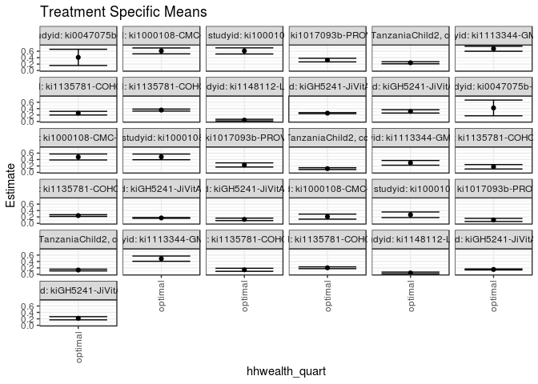

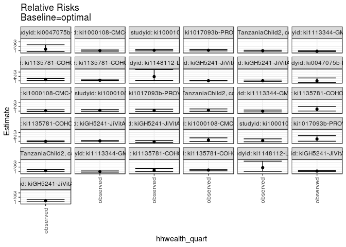

## Results Table

### Parameter: TSM

| agecat | studyid | country | intervention_level | baseline_level | estimate | ci_lower | ci_upper |
| --- | --- | --- | --- | --- | --- | --- | --- |
| 0-24 months | ki0047075b-MAL-ED | INDIA | optimal | NA | 0.4088015 | 0.1565411 | 0.6610619 |
| 0-24 months | ki1000108-CMC-V-BCS-2002 | INDIA | optimal | NA | 0.6107402 | 0.5187947 | 0.7026857 |
| 0-24 months | ki1000108-IRC | INDIA | optimal | NA | 0.6102825 | 0.5149609 | 0.7056042 |
| 0-24 months | ki1017093b-PROVIDE | BANGLADESH | optimal | NA | 0.3243911 | 0.2677359 | 0.3810462 |
| 0-24 months | ki1066203-TanzaniaChild2 | TANZANIA, UNITED REPUBLIC OF | optimal | NA | 0.2407922 | 0.2087401 | 0.2728444 |
| 0-24 months | ki1113344-GMS-Nepal | NEPAL | optimal | NA | 0.6780057 | 0.5997988 | 0.7562127 |
| 0-24 months | ki1135781-COHORTS | GUATEMALA | optimal | NA | 0.2575747 | 0.2002059 | 0.3149434 |
| 0-24 months | ki1135781-COHORTS | PHILIPPINES | optimal | NA | 0.3544253 | 0.3238877 | 0.3849629 |
| 0-24 months | ki1148112-LCNI-5 | MALAWI | optimal | NA | 0.0412259 | 0.0146814 | 0.0677704 |
| 0-24 months | kiGH5241-JiVitA-3 | BANGLADESH | optimal | NA | 0.2578123 | 0.2429726 | 0.2726520 |
| 0-24 months | kiGH5241-JiVitA-4 | BANGLADESH | optimal | NA | 0.3125404 | 0.2607754 | 0.3643055 |
| 0-6 months | ki0047075b-MAL-ED | INDIA | optimal | NA | 0.4206487 | 0.1752934 | 0.6660040 |
| 0-6 months | ki1000108-CMC-V-BCS-2002 | INDIA | optimal | NA | 0.4801794 | 0.3871503 | 0.5732085 |
| 0-6 months | ki1000108-IRC | INDIA | optimal | NA | 0.4833581 | 0.3944976 | 0.5722187 |
| 0-6 months | ki1017093b-PROVIDE | BANGLADESH | optimal | NA | 0.2319945 | 0.1670321 | 0.2969569 |
| 0-6 months | ki1066203-TanzaniaChild2 | TANZANIA, UNITED REPUBLIC OF | optimal | NA | 0.1168497 | 0.0887480 | 0.1449513 |
| 0-6 months | ki1113344-GMS-Nepal | NEPAL | optimal | NA | 0.2970597 | 0.2238675 | 0.3702520 |
| 0-6 months | ki1135781-COHORTS | GUATEMALA | optimal | NA | 0.1753191 | 0.1063609 | 0.2442774 |
| 0-6 months | ki1135781-COHORTS | PHILIPPINES | optimal | NA | 0.2420542 | 0.2150036 | 0.2691048 |
| 0-6 months | kiGH5241-JiVitA-3 | BANGLADESH | optimal | NA | 0.1692280 | 0.1568196 | 0.1816364 |
| 0-6 months | kiGH5241-JiVitA-4 | BANGLADESH | optimal | NA | 0.1237094 | 0.0848060 | 0.1626129 |
| 6-24 months | ki1000108-CMC-V-BCS-2002 | INDIA | optimal | NA | 0.2096465 | 0.1311104 | 0.2881825 |
| 6-24 months | ki1000108-IRC | INDIA | optimal | NA | 0.2669960 | 0.1797915 | 0.3542005 |
| 6-24 months | ki1017093b-PROVIDE | BANGLADESH | optimal | NA | 0.1070165 | 0.0585519 | 0.1554810 |
| 6-24 months | ki1066203-TanzaniaChild2 | TANZANIA, UNITED REPUBLIC OF | optimal | NA | 0.1336100 | 0.1066166 | 0.1606034 |
| 6-24 months | ki1113344-GMS-Nepal | NEPAL | optimal | NA | 0.4879251 | 0.4060087 | 0.5698415 |
| 6-24 months | ki1135781-COHORTS | GUATEMALA | optimal | NA | 0.1401706 | 0.0931160 | 0.1872251 |
| 6-24 months | ki1135781-COHORTS | PHILIPPINES | optimal | NA | 0.2037946 | 0.1755665 | 0.2320227 |
| 6-24 months | ki1148112-LCNI-5 | MALAWI | optimal | NA | 0.0422441 | 0.0152006 | 0.0692875 |
| 6-24 months | kiGH5241-JiVitA-3 | BANGLADESH | optimal | NA | 0.1517389 | 0.1358607 | 0.1676171 |
| 6-24 months | kiGH5241-JiVitA-4 | BANGLADESH | optimal | NA | 0.2181499 | 0.1683574 | 0.2679424 |

### Parameter: E(Y)

| agecat | studyid | country | intervention_level | baseline_level | estimate | ci_lower | ci_upper |
| --- | --- | --- | --- | --- | --- | --- | --- |
| 0-24 months | ki0047075b-MAL-ED | INDIA | observed | NA | 0.5492958 | 0.4327362 | 0.6658554 |
| 0-24 months | ki1000108-CMC-V-BCS-2002 | INDIA | observed | NA | 0.6139410 | 0.5644682 | 0.6634139 |
| 0-24 months | ki1000108-IRC | INDIA | observed | NA | 0.6560976 | 0.6100625 | 0.7021326 |
| 0-24 months | ki1017093b-PROVIDE | BANGLADESH | observed | NA | 0.3510029 | 0.3155698 | 0.3864359 |
| 0-24 months | ki1066203-TanzaniaChild2 | TANZANIA, UNITED REPUBLIC OF | observed | NA | 0.2365772 | 0.2195142 | 0.2536402 |
| 0-24 months | ki1113344-GMS-Nepal | NEPAL | observed | NA | 0.5913621 | 0.5520608 | 0.6306634 |
| 0-24 months | ki1135781-COHORTS | GUATEMALA | observed | NA | 0.3311367 | 0.2936667 | 0.3686068 |
| 0-24 months | ki1135781-COHORTS | PHILIPPINES | observed | NA | 0.4037451 | 0.3863123 | 0.4211779 |
| 0-24 months | ki1148112-LCNI-5 | MALAWI | observed | NA | 0.0807834 | 0.0620863 | 0.0994804 |
| 0-24 months | kiGH5241-JiVitA-3 | BANGLADESH | observed | NA | 0.2642331 | 0.2551503 | 0.2733160 |
| 0-24 months | kiGH5241-JiVitA-4 | BANGLADESH | observed | NA | 0.3184358 | 0.2901120 | 0.3467596 |
| 0-6 months | ki0047075b-MAL-ED | INDIA | observed | NA | 0.4225352 | 0.3068192 | 0.5382512 |
| 0-6 months | ki1000108-CMC-V-BCS-2002 | INDIA | observed | NA | 0.5190217 | 0.4679041 | 0.5701394 |
| 0-6 months | ki1000108-IRC | INDIA | observed | NA | 0.5439024 | 0.4956326 | 0.5921723 |
| 0-6 months | ki1017093b-PROVIDE | BANGLADESH | observed | NA | 0.2578797 | 0.2254025 | 0.2903568 |
| 0-6 months | ki1066203-TanzaniaChild2 | TANZANIA, UNITED REPUBLIC OF | observed | NA | 0.1392617 | 0.1253610 | 0.1531625 |
| 0-6 months | ki1113344-GMS-Nepal | NEPAL | observed | NA | 0.2956811 | 0.2591967 | 0.3321655 |
| 0-6 months | ki1135781-COHORTS | GUATEMALA | observed | NA | 0.2510373 | 0.2122871 | 0.2897876 |
| 0-6 months | ki1135781-COHORTS | PHILIPPINES | observed | NA | 0.2356227 | 0.2205417 | 0.2507038 |
| 0-6 months | kiGH5241-JiVitA-3 | BANGLADESH | observed | NA | 0.1822842 | 0.1742752 | 0.1902932 |
| 0-6 months | kiGH5241-JiVitA-4 | BANGLADESH | observed | NA | 0.1106095 | 0.0909057 | 0.1303132 |
| 6-24 months | ki1000108-CMC-V-BCS-2002 | INDIA | observed | NA | 0.2654155 | 0.2205451 | 0.3102860 |
| 6-24 months | ki1000108-IRC | INDIA | observed | NA | 0.3097561 | 0.2649438 | 0.3545684 |
| 6-24 months | ki1017093b-PROVIDE | BANGLADESH | observed | NA | 0.1615008 | 0.1323460 | 0.1906557 |
| 6-24 months | ki1066203-TanzaniaChild2 | TANZANIA, UNITED REPUBLIC OF | observed | NA | 0.1606965 | 0.1446374 | 0.1767556 |
| 6-24 months | ki1113344-GMS-Nepal | NEPAL | observed | NA | 0.4728814 | 0.4325613 | 0.5132014 |
| 6-24 months | ki1135781-COHORTS | GUATEMALA | observed | NA | 0.1783784 | 0.1464997 | 0.2102571 |
| 6-24 months | ki1135781-COHORTS | PHILIPPINES | observed | NA | 0.2666429 | 0.2502871 | 0.2829988 |
| 6-24 months | ki1148112-LCNI-5 | MALAWI | observed | NA | 0.0782609 | 0.0596958 | 0.0968259 |
| 6-24 months | kiGH5241-JiVitA-3 | BANGLADESH | observed | NA | 0.1648146 | 0.1556271 | 0.1740021 |
| 6-24 months | kiGH5241-JiVitA-4 | BANGLADESH | observed | NA | 0.2573427 | 0.2311603 | 0.2835250 |

### Parameter: RR

| agecat | studyid | country | intervention_level | baseline_level | estimate | ci_lower | ci_upper |
| --- | --- | --- | --- | --- | --- | --- | --- |
| 0-24 months | ki0047075b-MAL-ED | INDIA | observed | optimal | 1.3436736 | 0.7764992 | 2.3251264 |
| 0-24 months | ki1000108-CMC-V-BCS-2002 | INDIA | observed | optimal | 1.0052409 | 0.8793495 | 1.1491554 |
| 0-24 months | ki1000108-IRC | INDIA | observed | optimal | 1.0750718 | 0.9406516 | 1.2287008 |
| 0-24 months | ki1017093b-PROVIDE | BANGLADESH | observed | optimal | 1.0820361 | 0.9404185 | 1.2449799 |
| 0-24 months | ki1066203-TanzaniaChild2 | TANZANIA, UNITED REPUBLIC OF | observed | optimal | 0.9824951 | 0.8794834 | 1.0975723 |
| 0-24 months | ki1113344-GMS-Nepal | NEPAL | observed | optimal | 0.8722081 | 0.7881281 | 0.9652581 |
| 0-24 months | ki1135781-COHORTS | GUATEMALA | observed | optimal | 1.2855952 | 1.0714646 | 1.5425195 |
| 0-24 months | ki1135781-COHORTS | PHILIPPINES | observed | optimal | 1.1391542 | 1.0580607 | 1.2264630 |
| 0-24 months | ki1148112-LCNI-5 | MALAWI | observed | optimal | 1.9595281 | 1.0790976 | 3.5582975 |
| 0-24 months | kiGH5241-JiVitA-3 | BANGLADESH | observed | optimal | 1.0249051 | 0.9752227 | 1.0771185 |
| 0-24 months | kiGH5241-JiVitA-4 | BANGLADESH | observed | optimal | 1.0188626 | 0.8784285 | 1.1817478 |
| 0-6 months | ki0047075b-MAL-ED | INDIA | observed | optimal | 1.0044848 | 0.6083731 | 1.6585050 |
| 0-6 months | ki1000108-CMC-V-BCS-2002 | INDIA | observed | optimal | 1.0808913 | 0.9089017 | 1.2854261 |
| 0-6 months | ki1000108-IRC | INDIA | observed | optimal | 1.1252576 | 0.9604246 | 1.3183802 |
| 0-6 months | ki1017093b-PROVIDE | BANGLADESH | observed | optimal | 1.1115765 | 0.8689352 | 1.4219729 |
| 0-6 months | ki1066203-TanzaniaChild2 | TANZANIA, UNITED REPUBLIC OF | observed | optimal | 1.1918026 | 0.9584586 | 1.4819559 |
| 0-6 months | ki1113344-GMS-Nepal | NEPAL | observed | optimal | 0.9953589 | 0.8041916 | 1.2319694 |
| 0-6 months | ki1135781-COHORTS | GUATEMALA | observed | optimal | 1.4318878 | 1.0108686 | 2.0282584 |
| 0-6 months | ki1135781-COHORTS | PHILIPPINES | observed | optimal | 0.9734297 | 0.8901666 | 1.0644808 |
| 0-6 months | kiGH5241-JiVitA-3 | BANGLADESH | observed | optimal | 1.0771515 | 1.0116719 | 1.1468693 |
| 0-6 months | kiGH5241-JiVitA-4 | BANGLADESH | observed | optimal | 0.8941072 | 0.7038501 | 1.1357925 |
| 6-24 months | ki1000108-CMC-V-BCS-2002 | INDIA | observed | optimal | 1.2660150 | 0.9066275 | 1.7678638 |
| 6-24 months | ki1000108-IRC | INDIA | observed | optimal | 1.1601527 | 0.8711405 | 1.5450486 |
| 6-24 months | ki1017093b-PROVIDE | BANGLADESH | observed | optimal | 1.5091210 | 1.0010516 | 2.2750537 |
| 6-24 months | ki1066203-TanzaniaChild2 | TANZANIA, UNITED REPUBLIC OF | observed | optimal | 1.2027283 | 1.0114740 | 1.4301458 |
| 6-24 months | ki1113344-GMS-Nepal | NEPAL | observed | optimal | 0.9691679 | 0.8386514 | 1.1199962 |
| 6-24 months | ki1135781-COHORTS | GUATEMALA | observed | optimal | 1.2725809 | 0.9608004 | 1.6855346 |
| 6-24 months | ki1135781-COHORTS | PHILIPPINES | observed | optimal | 1.3083907 | 1.1565380 | 1.4801816 |
| 6-24 months | ki1148112-LCNI-5 | MALAWI | observed | optimal | 1.8525887 | 1.0260417 | 3.3449758 |
| 6-24 months | kiGH5241-JiVitA-3 | BANGLADESH | observed | optimal | 1.0861723 | 0.9908949 | 1.1906109 |
| 6-24 months | kiGH5241-JiVitA-4 | BANGLADESH | observed | optimal | 1.1796598 | 0.9609000 | 1.4482228 |

### Parameter: PAR

| agecat | studyid | country | intervention_level | baseline_level | estimate | ci_lower | ci_upper |
| --- | --- | --- | --- | --- | --- | --- | --- |
| 0-24 months | ki0047075b-MAL-ED | INDIA | optimal | NA | 0.1404943 | -0.0811578 | 0.3621464 |
| 0-24 months | ki1000108-CMC-V-BCS-2002 | INDIA | optimal | NA | 0.0032008 | -0.0785374 | 0.0849390 |
| 0-24 months | ki1000108-IRC | INDIA | optimal | NA | 0.0458150 | -0.0354836 | 0.1271136 |
| 0-24 months | ki1017093b-PROVIDE | BANGLADESH | optimal | NA | 0.0266118 | -0.0189111 | 0.0721347 |
| 0-24 months | ki1066203-TanzaniaChild2 | TANZANIA, UNITED REPUBLIC OF | optimal | NA | -0.0042150 | -0.0308918 | 0.0224617 |
| 0-24 months | ki1113344-GMS-Nepal | NEPAL | optimal | NA | -0.0866436 | -0.1550189 | -0.0182683 |
| 0-24 months | ki1135781-COHORTS | GUATEMALA | optimal | NA | 0.0735621 | 0.0266233 | 0.1205009 |
| 0-24 months | ki1135781-COHORTS | PHILIPPINES | optimal | NA | 0.0493198 | 0.0230948 | 0.0755447 |
| 0-24 months | ki1148112-LCNI-5 | MALAWI | optimal | NA | 0.0395574 | 0.0134732 | 0.0656416 |
| 0-24 months | kiGH5241-JiVitA-3 | BANGLADESH | optimal | NA | 0.0064208 | -0.0064134 | 0.0192551 |
| 0-24 months | kiGH5241-JiVitA-4 | BANGLADESH | optimal | NA | 0.0058953 | -0.0405089 | 0.0522996 |
| 0-6 months | ki0047075b-MAL-ED | INDIA | optimal | NA | 0.0018865 | -0.2090190 | 0.2127921 |
| 0-6 months | ki1000108-CMC-V-BCS-2002 | INDIA | optimal | NA | 0.0388423 | -0.0447086 | 0.1223933 |
| 0-6 months | ki1000108-IRC | INDIA | optimal | NA | 0.0605443 | -0.0160450 | 0.1371336 |
| 0-6 months | ki1017093b-PROVIDE | BANGLADESH | optimal | NA | 0.0258851 | -0.0312403 | 0.0830105 |
| 0-6 months | ki1066203-TanzaniaChild2 | TANZANIA, UNITED REPUBLIC OF | optimal | NA | 0.0224121 | -0.0031268 | 0.0479510 |
| 0-6 months | ki1113344-GMS-Nepal | NEPAL | optimal | NA | -0.0013787 | -0.0647316 | 0.0619743 |
| 0-6 months | ki1135781-COHORTS | GUATEMALA | optimal | NA | 0.0757182 | 0.0146052 | 0.1368312 |
| 0-6 months | ki1135781-COHORTS | PHILIPPINES | optimal | NA | -0.0064315 | -0.0280934 | 0.0152305 |
| 0-6 months | kiGH5241-JiVitA-3 | BANGLADESH | optimal | NA | 0.0130562 | 0.0023769 | 0.0237355 |
| 0-6 months | kiGH5241-JiVitA-4 | BANGLADESH | optimal | NA | -0.0130999 | -0.0430599 | 0.0168600 |
| 6-24 months | ki1000108-CMC-V-BCS-2002 | INDIA | optimal | NA | 0.0557691 | -0.0148414 | 0.1263796 |
| 6-24 months | ki1000108-IRC | INDIA | optimal | NA | 0.0427601 | -0.0337120 | 0.1192323 |
| 6-24 months | ki1017093b-PROVIDE | BANGLADESH | optimal | NA | 0.0544843 | 0.0097295 | 0.0992392 |
| 6-24 months | ki1066203-TanzaniaChild2 | TANZANIA, UNITED REPUBLIC OF | optimal | NA | 0.0270865 | 0.0038548 | 0.0503183 |
| 6-24 months | ki1113344-GMS-Nepal | NEPAL | optimal | NA | -0.0150437 | -0.0856299 | 0.0555424 |
| 6-24 months | ki1135781-COHORTS | GUATEMALA | optimal | NA | 0.0382078 | -0.0016537 | 0.0780693 |
| 6-24 months | ki1135781-COHORTS | PHILIPPINES | optimal | NA | 0.0628484 | 0.0374644 | 0.0882323 |
| 6-24 months | ki1148112-LCNI-5 | MALAWI | optimal | NA | 0.0360168 | 0.0097616 | 0.0622720 |
| 6-24 months | kiGH5241-JiVitA-3 | BANGLADESH | optimal | NA | 0.0130757 | -0.0009156 | 0.0270670 |
| 6-24 months | kiGH5241-JiVitA-4 | BANGLADESH | optimal | NA | 0.0391928 | -0.0057604 | 0.0841459 |

### Parameter: PAF

| agecat | studyid | country | intervention_level | baseline_level | estimate | ci_lower | ci_upper |
| --- | --- | --- | --- | --- | --- | --- | --- |
| 0-24 months | ki0047075b-MAL-ED | INDIA | optimal | NA | 0.2557717 | -0.2878313 | 0.5699159 |
| 0-24 months | ki1000108-CMC-V-BCS-2002 | INDIA | optimal | NA | 0.0052135 | -0.1372043 | 0.1297957 |
| 0-24 months | ki1000108-IRC | INDIA | optimal | NA | 0.0698296 | -0.0630929 | 0.1861322 |
| 0-24 months | ki1017093b-PROVIDE | BANGLADESH | optimal | NA | 0.0758164 | -0.0633563 | 0.1967742 |
| 0-24 months | ki1066203-TanzaniaChild2 | TANZANIA, UNITED REPUBLIC OF | optimal | NA | -0.0178167 | -0.1370311 | 0.0888983 |
| 0-24 months | ki1113344-GMS-Nepal | NEPAL | optimal | NA | -0.1465153 | -0.2688293 | -0.0359923 |
| 0-24 months | ki1135781-COHORTS | GUATEMALA | optimal | NA | 0.2221502 | 0.0666980 | 0.3517100 |
| 0-24 months | ki1135781-COHORTS | PHILIPPINES | optimal | NA | 0.1221557 | 0.0548746 | 0.1846472 |
| 0-24 months | ki1148112-LCNI-5 | MALAWI | optimal | NA | 0.4896730 | 0.0732998 | 0.7189667 |
| 0-24 months | kiGH5241-JiVitA-3 | BANGLADESH | optimal | NA | 0.0242999 | -0.0254069 | 0.0715970 |
| 0-24 months | kiGH5241-JiVitA-4 | BANGLADESH | optimal | NA | 0.0185134 | -0.1383966 | 0.1537958 |
| 0-6 months | ki0047075b-MAL-ED | INDIA | optimal | NA | 0.0044648 | -0.6437283 | 0.3970473 |
| 0-6 months | ki1000108-CMC-V-BCS-2002 | INDIA | optimal | NA | 0.0748376 | -0.1002290 | 0.2220478 |
| 0-6 months | ki1000108-IRC | INDIA | optimal | NA | 0.1113146 | -0.0412062 | 0.2414935 |
| 0-6 months | ki1017093b-PROVIDE | BANGLADESH | optimal | NA | 0.1003768 | -0.1508338 | 0.2967517 |
| 0-6 months | ki1066203-TanzaniaChild2 | TANZANIA, UNITED REPUBLIC OF | optimal | NA | 0.1609349 | -0.0433418 | 0.3252161 |
| 0-6 months | ki1113344-GMS-Nepal | NEPAL | optimal | NA | -0.0046627 | -0.2434848 | 0.1882915 |
| 0-6 months | ki1135781-COHORTS | GUATEMALA | optimal | NA | 0.3016213 | 0.0107517 | 0.5069662 |
| 0-6 months | ki1135781-COHORTS | PHILIPPINES | optimal | NA | -0.0272956 | -0.1233852 | 0.0605749 |
| 0-6 months | kiGH5241-JiVitA-3 | BANGLADESH | optimal | NA | 0.0716255 | 0.0115372 | 0.1280611 |
| 0-6 months | kiGH5241-JiVitA-4 | BANGLADESH | optimal | NA | -0.1184341 | -0.4207571 | 0.1195575 |
| 6-24 months | ki1000108-CMC-V-BCS-2002 | INDIA | optimal | NA | 0.2101199 | -0.1029888 | 0.4343456 |
| 6-24 months | ki1000108-IRC | INDIA | optimal | NA | 0.1380445 | -0.1479205 | 0.3527712 |
| 6-24 months | ki1017093b-PROVIDE | BANGLADESH | optimal | NA | 0.3373626 | 0.0010505 | 0.5604499 |
| 6-24 months | ki1066203-TanzaniaChild2 | TANZANIA, UNITED REPUBLIC OF | optimal | NA | 0.1685570 | 0.0113439 | 0.3007706 |
| 6-24 months | ki1113344-GMS-Nepal | NEPAL | optimal | NA | -0.0318129 | -0.1923905 | 0.1071399 |
| 6-24 months | ki1135781-COHORTS | GUATEMALA | optimal | NA | 0.2141954 | -0.0407989 | 0.4067164 |
| 6-24 months | ki1135781-COHORTS | PHILIPPINES | optimal | NA | 0.2357023 | 0.1353505 | 0.3244072 |
| 6-24 months | ki1148112-LCNI-5 | MALAWI | optimal | NA | 0.4602148 | 0.0253808 | 0.7010442 |
| 6-24 months | kiGH5241-JiVitA-3 | BANGLADESH | optimal | NA | 0.0793358 | -0.0091888 | 0.1600950 |
| 6-24 months | kiGH5241-JiVitA-4 | BANGLADESH | optimal | NA | 0.1522980 | -0.0406911 | 0.3094985 |